# Spruce needles seasonal differential expression analysis

Nicolas Delhomme

2018-05-03

# 1 Setup

Environment Set the working dir

```r
setwd("/mnt/picea/projects/spruce/sjansson/seasonal-needles/u2015030/")
```

Libraries

```r
suppressPackageStartupMessages(library(DESeq2))
suppressPackageStartupMessages(library(KEGGREST))
suppressPackageStartupMessages(library(LSD))
suppressPackageStartupMessages(library(vsn))
suppressPackageStartupMessages(library(wordcloud))
```

Helpers

```r
suppressPackageStartupMessages(source("~/Git/UPSCb/src/R/featureSelection.R"))
suppressPackageStartupMessages(source("~/Git/UPSCb/src/R/gopher.R"))
suppressPackageStartupMessages(source("~/Git/UPSCb/src/R/volcanoPlot.R"))
```

Palette

```r
hpal <- colorRampPalette(colors = c("blue","red"))(100)
```

# 2 Pre-process

## 2.1 Seasons

Read (Meta)Data

```r
load("vst_aware.rda")
```

### 2.1.1 Filter

Focus on one year of sampling - samples past 2012-04-24 are the next generation of needles

```r
sel <- ordered_dates %in% levels(ordered_dates)[1:(grep("2012-05",levels(ordered_dates))[1]-1)]
ord_dates <- factor(as.character(ordered_dates)[sel])
vst_aware <- vst_aware[,sel]
```

### 2.1.2 Hierarchical clustering

We define 5 seasons:

- spring: March - April
- early-summer: May - June
- summer: July-August
- autumn: September
- winter: October-February

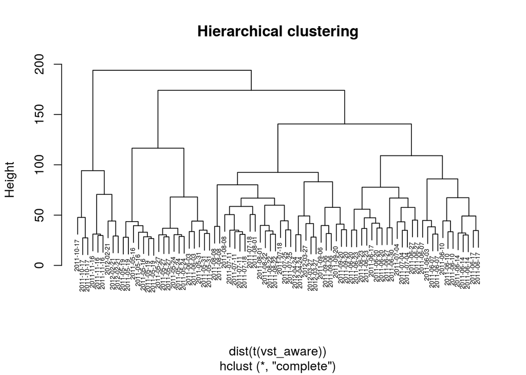

```r
hc <- hclust(dist(t(vst_aware)))
plot(hc, main = "Hierarchical clustering",labels = ord_dates,cex=0.5)
```

```r
seasons <- data.frame(month=sprintf("%02d",1:12),
                      season=c(rep("winter",2),
                               rep("spring",2),
                               rep("early.summer",2),
                               rep("late.summer",2),
                               "autumn",
                               rep("winter",3)))

save(seasons,file="seasons-for-vst-aware.rda")
```

## 2.2 Raw data

### 2.2.1 Raw counts

```r
load("kt_tech_merged_cropped_ordered.rda")
kt_tech_merged_cropped_ordered <- kt_tech_merged_cropped_ordered[,match(colnames(vst_aware),colnames(kt_tech_merged_cropped_ordered))]
stopifnot(colnames(vst_aware)==colnames(kt_tech_merged_cropped_ordered))
```

### 2.2.2 DESeq2 object

```r
dds <- DESeqDataSetFromMatrix(countData = kt_tech_merged_cropped_ordered,
                              colData = data.frame(season=seasons$season[match(sapply(strsplit(as.character(ord_dates),"-"),"[",2),
                                                                               seasons$month)]),
                              design = ~season)
```

## 2.3 Differential Expression

```r
dds <- DESeq(dds)
```

```
## -- replacing outliers and refitting for 180 genes
## -- DESeq argument 'minReplicatesForReplace' = 7
## -- original counts are preserved in counts(dds)
```

Cutoffs as devised from Schurch et al, RNA, 2016 We compare 6 (autumn) vs. 9 (winter) and 9 (winter) vs. 5 (spring), respectively

```r
alpha=0.01
lfc=0.5
```

### 2.3.1 Autumn vs. Winter

```r
res <- results(dds,c("season","autumn","winter"))
```

*MA plot*

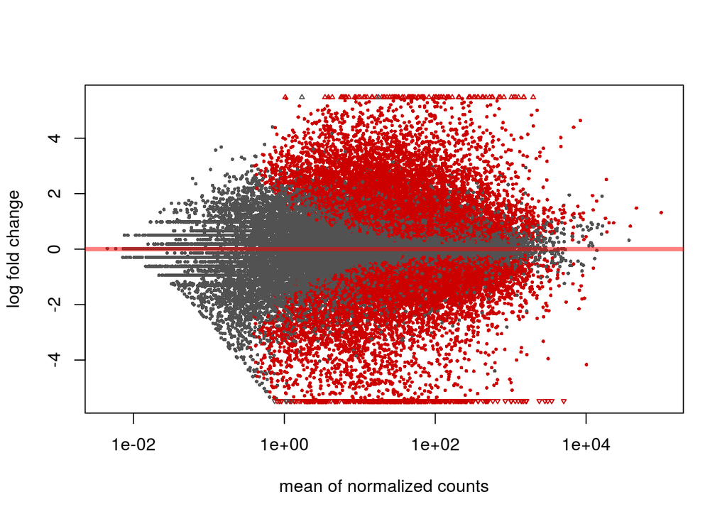

```r
DESeq2::plotMA(res)
```

*Volcanoplot*

Given what we know from the seasonal effect (overall less expressed genes in winter but which are on average more expressed due to the library size estimation), we should consider larger fold changes as relevant. The seasonal effect analysis suggest a cutoff of at least 2 fold changes. The normalisation effect is actually visible in the volcano-plot as the orange and yellow dots (at x=~0 and y=~0), that show a consistent shift from 0 towards either season.

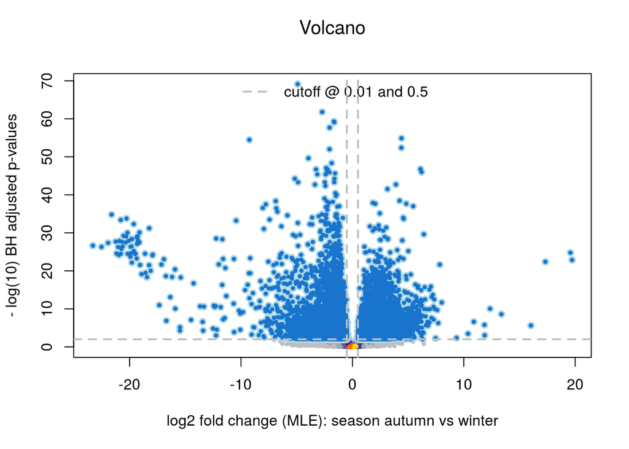

```r
volcanoPlot(res)
```

```r
lfc=2
```

*Tables*

```r
dir.create("analysis/DESeq2",showWarnings = FALSE)
write.table(res,file="analysis/DESeq2/autumn-vs-winter_DE.txt",
            sep="\t",quote = FALSE)

avsw <- sub("\\.1$","",rownames(res)[!is.na(res$padj) & res$padj <= alpha & abs(res$log2FoldChange) > lfc])
write.table(avsw,file="analysis/DESeq2/autumn-vs-winter_DE-gene-IDs.txt",
            sep="\t",quote = FALSE,col.names = FALSE, row.names = FALSE)
```

### 2.3.2 Winter vs. Spring

```r
res <- results(dds,c("season","winter","spring"))
```

*MA plot*

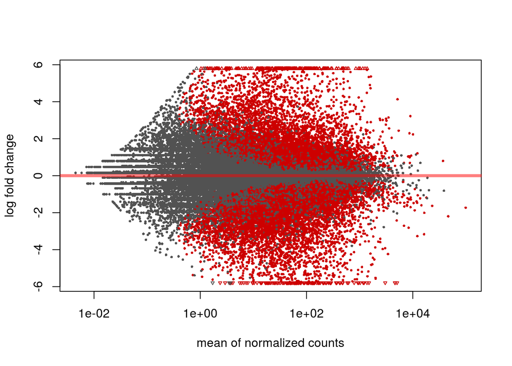

```r
DESeq2::plotMA(res)
```

*Volcanoplot*

Given what we know from the seasonal effect (overall less expressed genes in winter but which are on average more expressed due to the library size estimation), we should consider larger fold changes as relevant. The seasonal effect analysis suggest a cutoff of at least 2 fold changes. The normalisation effect is actually visible in the volcano-plot as the orange and yellow dots (at x=~0 and y=~0), that show a consistent shift from 0 towards either season.

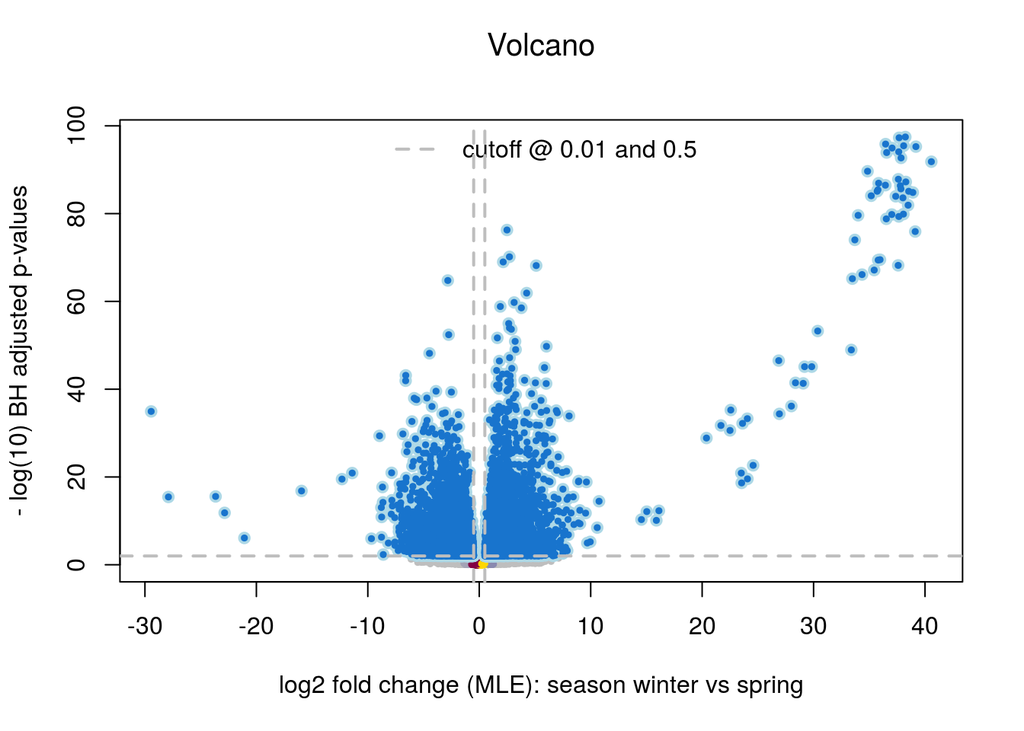

```r
volcanoPlot(res)
```

```r
alpha=0.01
lfc=2
```

*Tables*

```r
write.table(res,file="analysis/DESeq2/winter-vs-spring_DE.txt",
            sep="\t",quote = FALSE)

wvss <- sub("\\.1$","",rownames(res)[!is.na(res$padj) & res$padj <= alpha & abs(res$log2FoldChange) > lfc])
write.table(wvss,file="analysis/DESeq2/winter-vs-spring_DE-gene-IDs.txt",
            sep="\t",quote = FALSE,col.names = FALSE, row.names = FALSE)
```

## 2.4 Gene Ontology

### 2.4.1 The population

```r
vsd <- varianceStabilizingTransformation(dds,blind = FALSE)
vst <- assay(vsd)
vst <- vst - min(vst)
```

The VST is satisfying

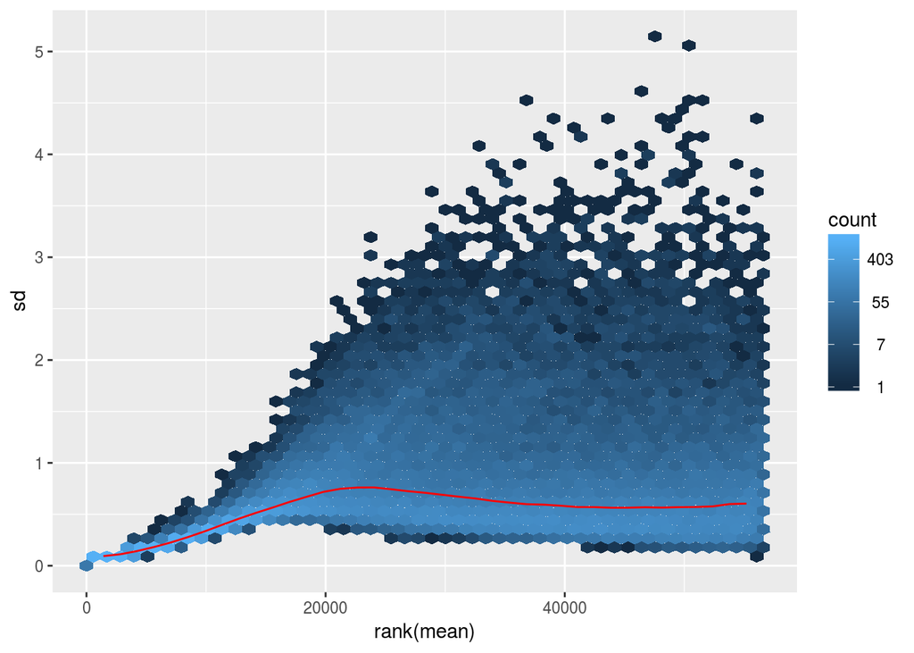

```r
meanSdPlot(vst[rowSums(vst)>0,])
```

Devise the population

```r
pop <- sub("\\.1$","",rownames(vst)[featureSelect(vst,colData(dds)$season)])
stopifnot(all(avsw %in% pop))
stopifnot(all(wvss %in% pop))
```

### 2.4.2 Autumn vs. Winter

```r
enrichment <- gopher(avsw,
                     task = list("go","kegg","pfam"),
                     background = pop,url="pabies")
```

#### 2.4.2.1 GO

Filter for OBSOLETE

```r
enrichment$go <- enrichment$go[!grepl("^OBSOLETE.",enrichment$go$def),]
stopifnot(all(0 <= as.numeric(enrichment$go$padj) & as.numeric(enrichment$go$padj) <= 1))
```

Save

```r
write.table(enrichment$go,file="analysis/DESeq2/autumn-vs-winter_GO.txt",
      sep="\t",quote = FALSE, row.names=FALSE)

write.table(enrichment$go[,c("id","padj")],file="analysis/DESeq2/autumn-vs-winter_REVIGO-input.txt",
            sep="\t",quote = FALSE, row.names=FALSE, col.names = FALSE)
```

#### 2.4.2.2 KEGG

```r
alpha=.1
write.table(enrichment$kegg,file="analysis/DESeq2/autumn-vs-winter_KEGG.txt",
            sep="\t",quote = FALSE, row.names=FALSE)
```

Find the pathway of the significantly enriched enzymes

```r
pathways <- keggLink("pathway",enrichment$kegg$id[enrichment$kegg$padj<=alpha])
```

Pathways are duplicated, clean up

```r
stopifnot(length(grep("map",pathways)) == length(grep("ec",pathways)))
pathways <- pathways[grep("map",pathways)]
```

Proportion of the pathways

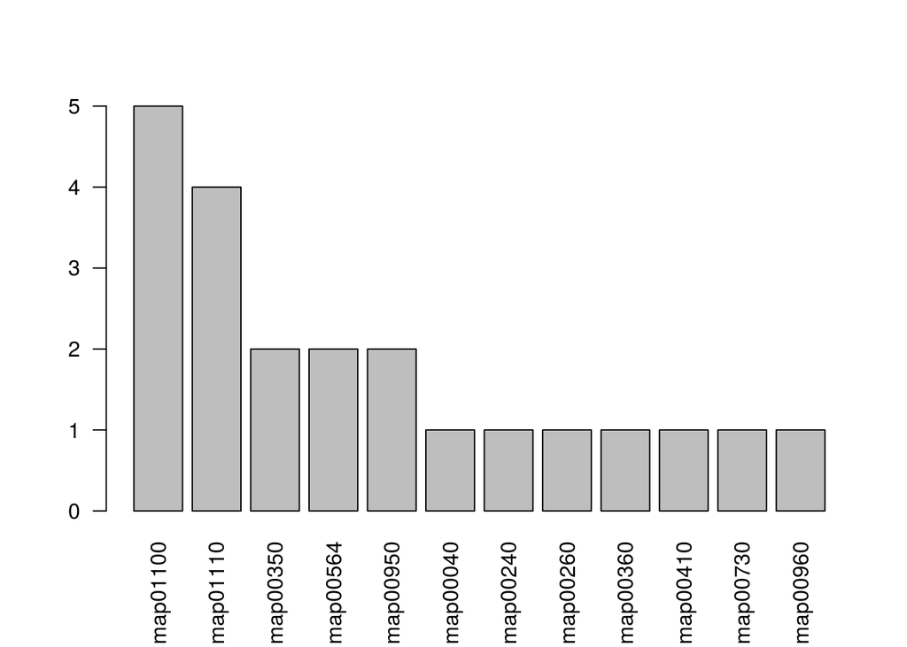

```r
barplot(sort(table(sub("path:","",pathways)),decreasing = TRUE),las=2)
```

Get the pathway info

```r
pinfo <- lapply(split(unique(pathways), ceiling(seq_along(unique(pathways))/10)),keggGet)

pathway.df <- do.call(rbind,lapply(pinfo,function(x){data.frame(ENTRY=sapply(x,"[[","ENTRY"),
                                                                NAME=sapply(x,"[[","NAME"))}))
tab <- table(sub("path:","",pathways))

pathway.df$OCCURENCE <- tab[match(pathway.df$ENTRY,names(tab))]

write.table(pathway.df,file="analysis/DESeq2/autumn-vs-winter_KEGG-pathway.txt",
            sep="\t",quote = FALSE, row.names=FALSE)
```

Create a wordcloud of the pathway names

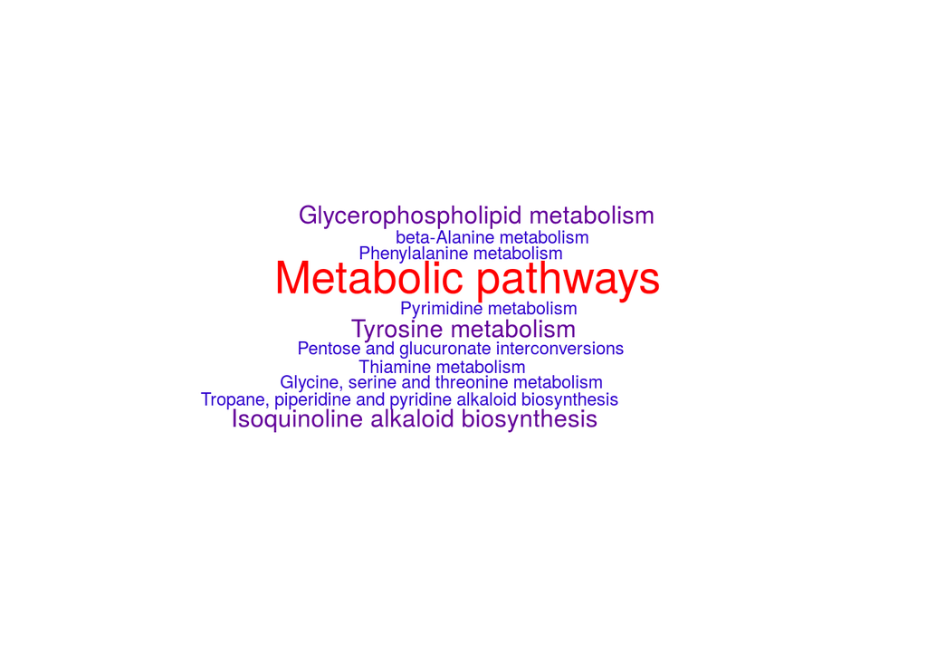

```r
wordcloud(pathway.df$NAME,pathway.df$OCCURENCE/sum(pathway.df$OCCURENCE),
          colors = hpal,scale = c(2,.5),rot.per = 0)
```

#### 2.4.2.3 PFAM

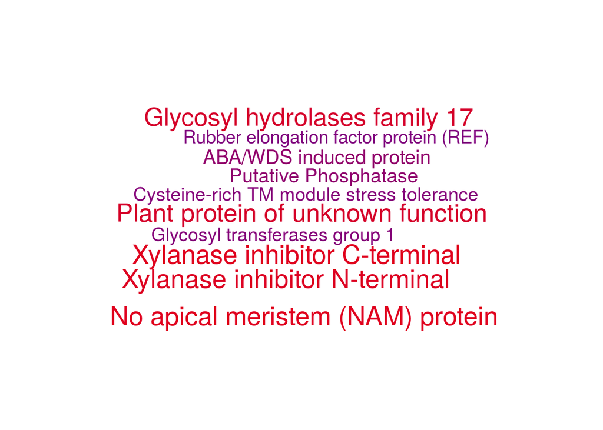

```r
alpha <- 0.01
write.table(enrichment$pfam,file="analysis/DESeq2/autumn-vs-winter_PFAM.txt",
            sep="\t",quote = FALSE, row.names=FALSE)

wordcloud(enrichment$pfam[enrichment$pfam$padj <= alpha,"name"],
          (as.integer(enrichment$pfam[enrichment$pfam$padj <= alpha,"nt"])/
            as.integer(enrichment$pfam[enrichment$pfam$padj <= alpha,"mt"])) *
            (as.integer(enrichment$pfam[enrichment$pfam$padj <= alpha,"nt"]) /
            as.integer(enrichment$pfam[enrichment$pfam$padj <= alpha,"n"])),
          colors = hpal,scale = c(2,.5),rot.per = 0)
```

### 2.4.3 Winter vs. Spring

```r
enrichment <- gopher(wvss,
                     task = list("go","kegg","pfam"),
                     background = pop,url="pabies")
```

#### 2.4.3.1 GO

Filter out OBSOLETE terms

```r
enrichment$go <- enrichment$go[!grepl("^OBSOLETE.",enrichment$go$def),]
stopifnot(all(0 <= as.numeric(enrichment$go$padj) & as.numeric(enrichment$go$padj) <= 1))
```

Save the results

```r
write.table(enrichment$go,file="analysis/DESeq2/winter-vs-spring_GO.txt",
            sep="\t",quote = FALSE, row.names=FALSE)

write.table(enrichment$go[,c("id","padj")],file="analysis/DESeq2/winter-vs-spring_REVIGO-input.txt",
            sep="\t",quote = FALSE, row.names=FALSE, col.names = FALSE)
```

#### 2.4.3.2 KEGG

```r
alpha=.1
write.table(enrichment$kegg,file="analysis/DESeq2/winter-vs-spring_KEGG.txt",
            sep="\t",quote = FALSE, row.names=FALSE)
```

Find the pathway of the significantly enriched enzymes

```r
pathways <- keggLink("pathway",enrichment$kegg$id[enrichment$kegg$padj<=alpha])
```

Pathways are duplicated, clean up

```r
stopifnot(length(grep("map",pathways)) == length(grep("ec",pathways)))
pathways <- pathways[grep("map",pathways)]
```

Proportion of the pathways

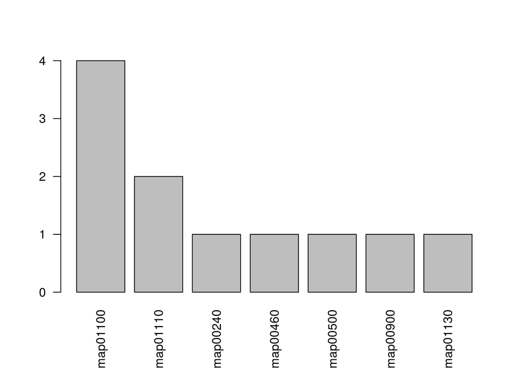

```r
barplot(sort(table(sub("path:","",pathways)),decreasing = TRUE),las=2)
```

Get the pathway info

```r
pinfo <- lapply(split(unique(pathways), ceiling(seq_along(unique(pathways))/10)),keggGet)

pathway.df <- do.call(rbind,lapply(pinfo,function(x){data.frame(ENTRY=sapply(x,"[[","ENTRY"),
                                                          NAME=sapply(x,"[[","NAME"))}))

tab <- table(sub("path:","",pathways))

pathway.df$OCCURENCE <- tab[match(pathway.df$ENTRY,names(tab))]

write.table(pathway.df,file="analysis/DESeq2/winter-vs-spring_KEGG-pathway.txt",
            sep="\t",quote = FALSE, row.names=FALSE)
```

Create a wordcloud of the pathway names

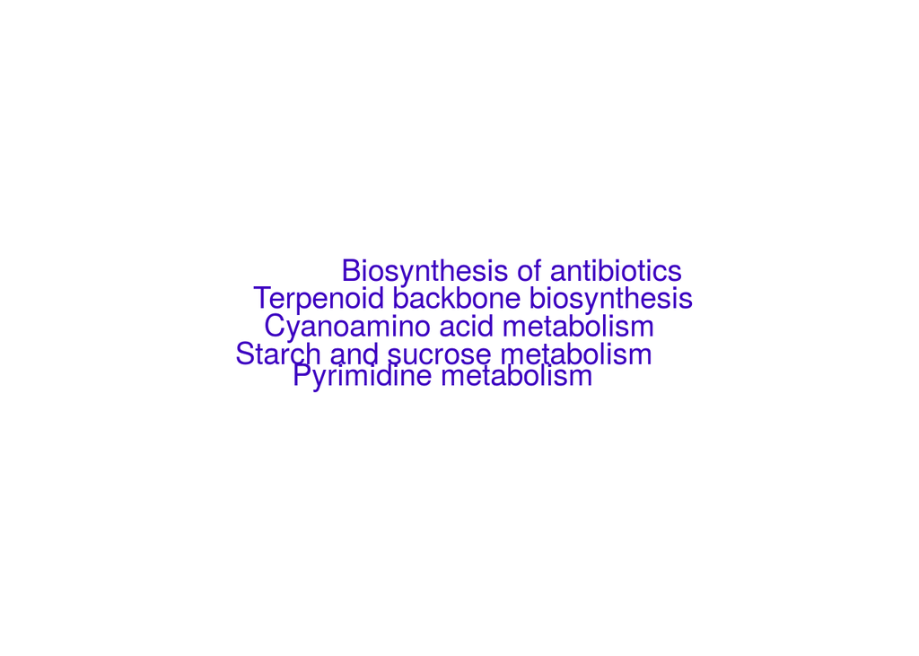

```r
wordcloud(pathway.df$NAME,pathway.df$OCCURENCE/sum(pathway.df$OCCURENCE),
          colors = hpal,rot.per = 0)
```

#### 2.4.3.3 PFAM

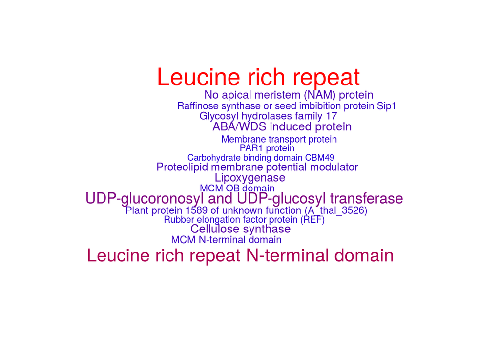

```r
alpha <- 0.01
write.table(enrichment$pfam,file="analysis/DESeq2/winter-vs-spring_PFAM.txt",
            sep="\t",quote = FALSE, row.names=FALSE)

wordcloud(enrichment$pfam[enrichment$pfam$padj <= alpha,"name"],
          (as.integer(enrichment$pfam[enrichment$pfam$padj <= alpha,"nt"])/
             as.integer(enrichment$pfam[enrichment$pfam$padj <= alpha,"mt"])) *
            (as.integer(enrichment$pfam[enrichment$pfam$padj <= alpha,"nt"]) /
               as.integer(enrichment$pfam[enrichment$pfam$padj <= alpha,"n"])),
          colors = hpal,scale = c(2,.5),rot.per = 0)
```